# Your Digital Legacy

2008-05-01

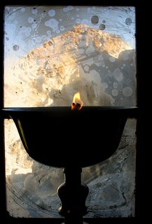

I’m a big fan of Nate Weiner’s [Idea Shower](http://www.ideashower.com/). He recently wrote a really good [blog post](http://www.ideashower.com/blog/what-will-the-web-see-when-you-die/) entitled “What Will the Web See When You Die?” In it, he wrote about the death of a snowboarding colleague, and how the traditional media publications cobbled a rather terse biography of the man by copying some of his profile information from a company website. His post was a good read. [Go read it](http://www.ideashower.com/blog/what-will-the-web-see-when-you-die/). Check out his other stuff, too, he’s brilliant.

Anyway, the story reminded me of one of my former colleagues who committed suicide a few years ago (in fact, I left a comment about it on Nate’s blog… most of this post is just an expansion of that comment!). He died several years after we had drifted apart (he had moved out to the west coast, and I moved back up to Maine), so I didn’t find out about it until months after it happened. After I found out, the first thing that I did was go to his web site. There he was, smiling at the camera for a blog entry about how his and his girlfriend’s guacamole dip recipe. I found it rather eerie that his web site stayed up for so long after his death. I found myself re-visiting it days later, perhaps I was half-expecting new content to magically appear. Eventually the site just disappeared into the ether.

At the time I wondered if I should keep a copy of it and host it as sort of a tribute to him, but in the end I decided it was better to let the site go with him; keeping it was like the parents you read about who lose a child and can’t bring themselves to redecorate their room. I doubt he would’ve wanted that.

In this age of caching pages and leaving parts of yourself scattered over the social web, it’s interesting to think that digital bits of your life will live on long after you die. Our lives are far shorter than the magnetic tapes and spinning disks that prop up the web. In fact, my friend’s pages are still in the [internet wayback machine](http://www.archive.org/web/web.php), so I didn’t even need to save them.

Photo Credit: [ReefRaff](http://flickr.com/people/payalvora/)

[This work is licensed under a [Creative Commons Attribution-NonCommercial-NoDerivatives 4.0 International License](http://creativecommons.org/licenses/by-nc-nd/4.0/) .](http://creativecommons.org/licenses/by-nc-nd/4.0/)